# Additional Data Analysis for the ERD experiment

## Prob x Decision

The following set of figures shows the boxplot summary for the probability of receiving the product before the runway and the decision across conditions and trials.

### Prob x Dec: Week 1

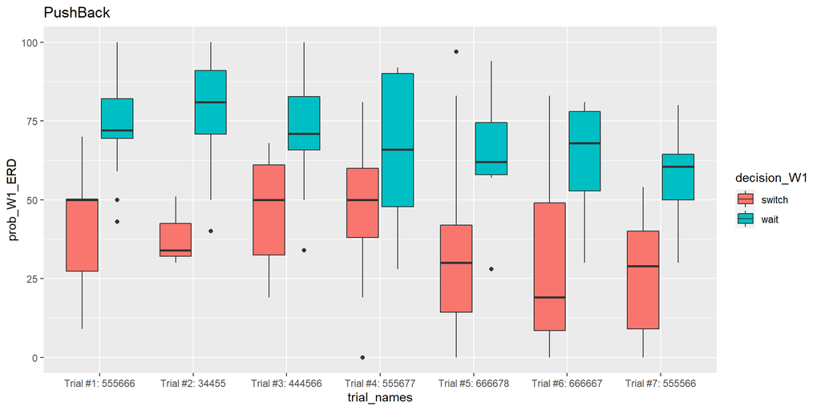

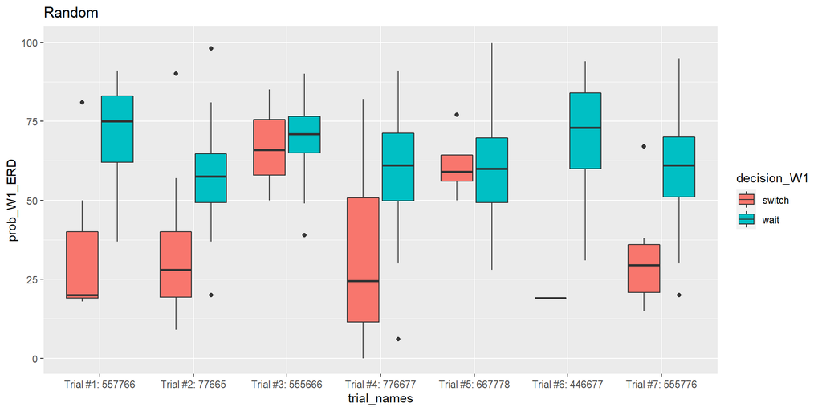

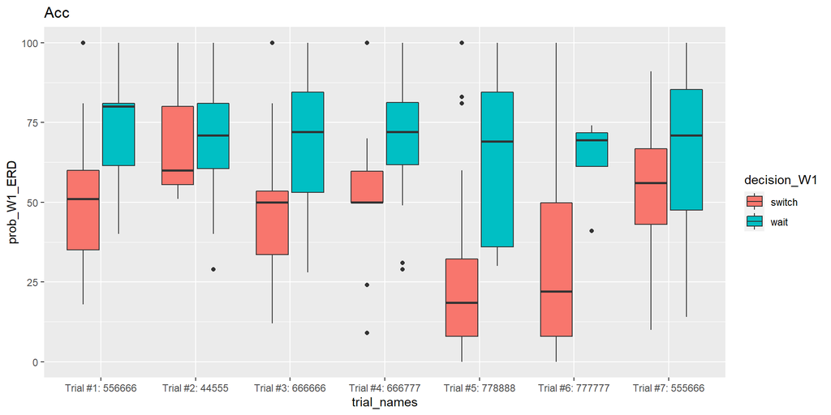

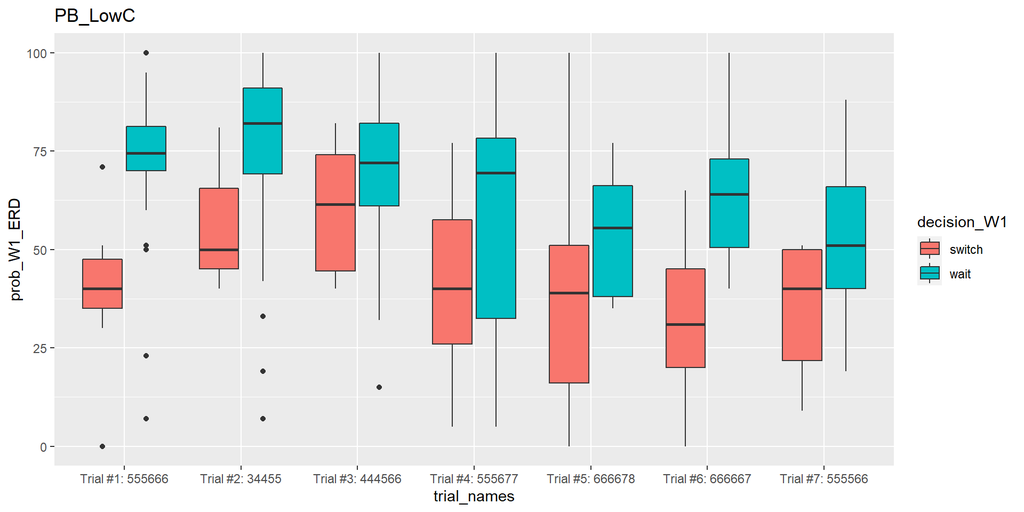

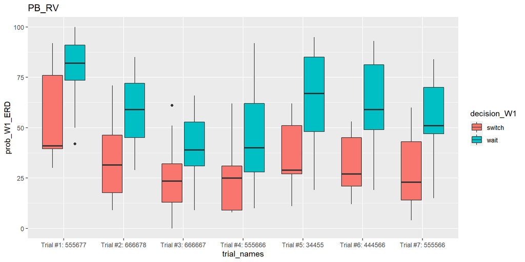

### Prob x Dec: Week 3

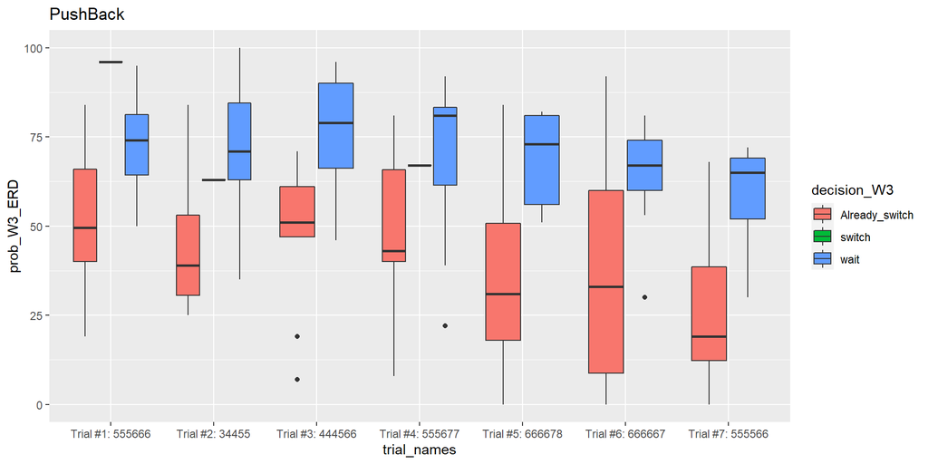

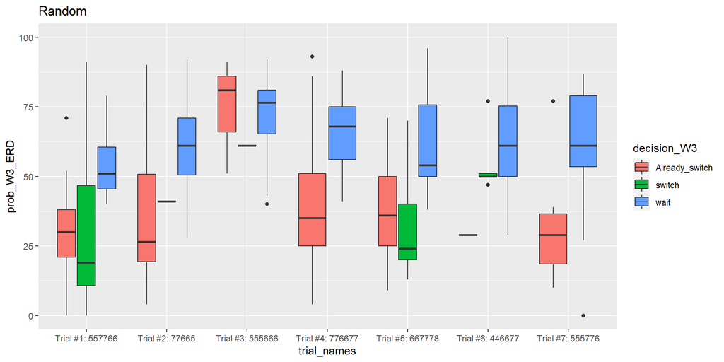

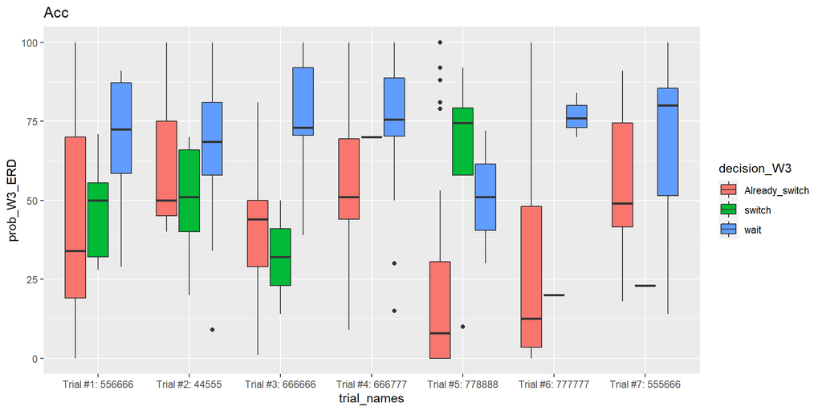

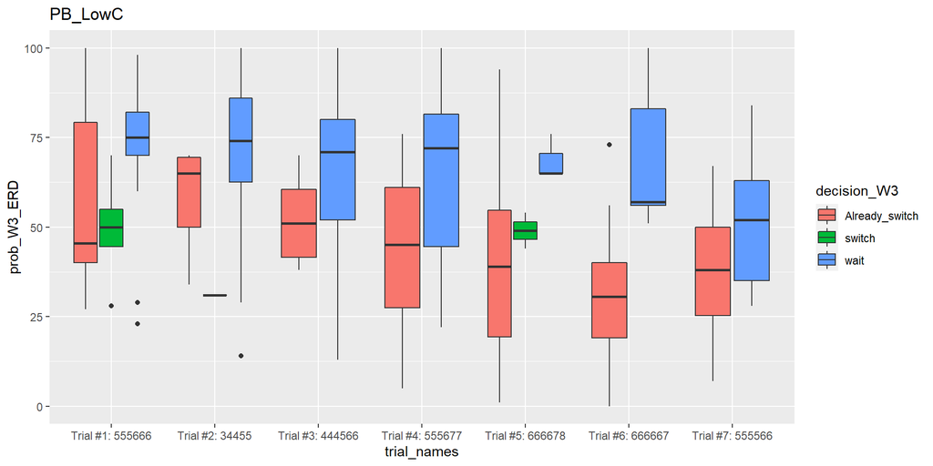

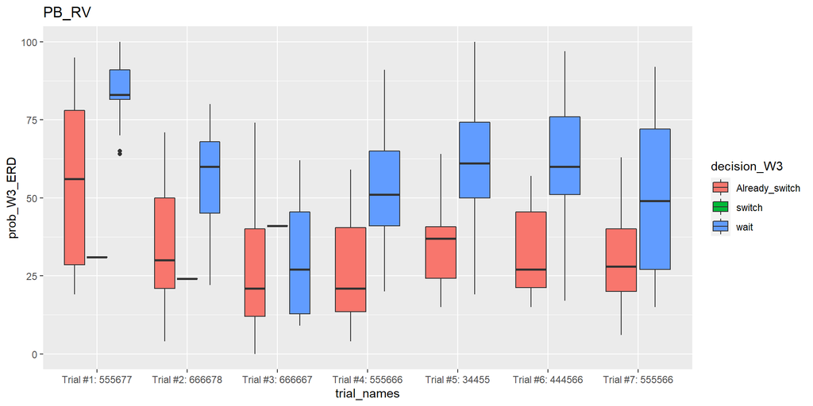

### ProbxDec: Trial #7

Here, we look specifically at trial 7 for week 1 and 3.

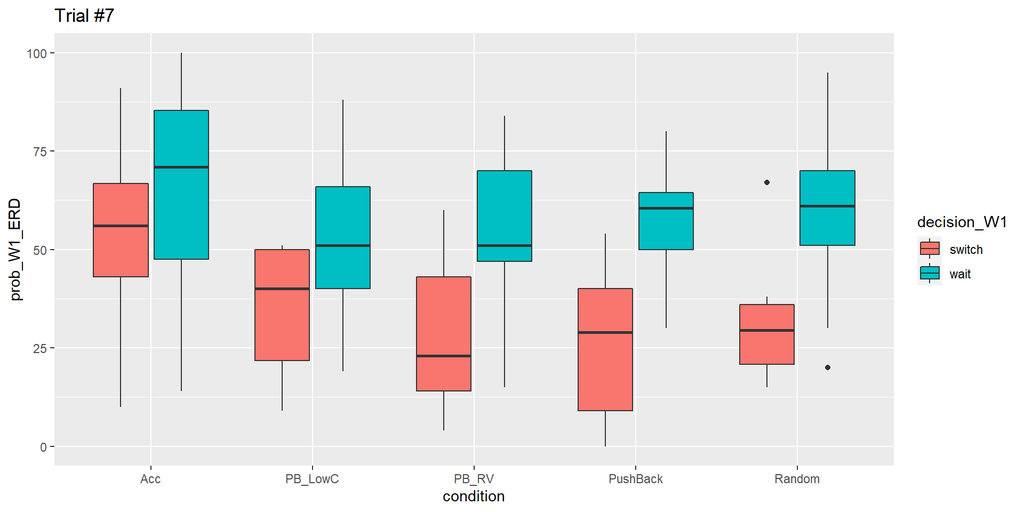

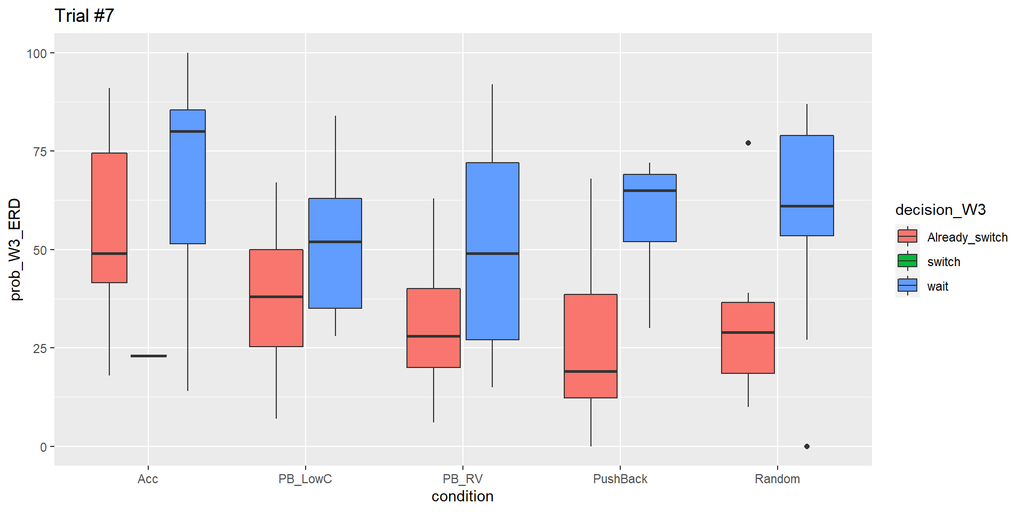

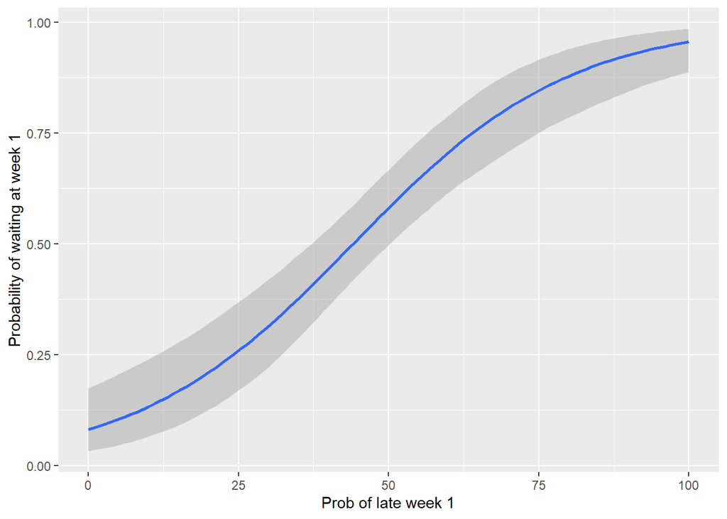

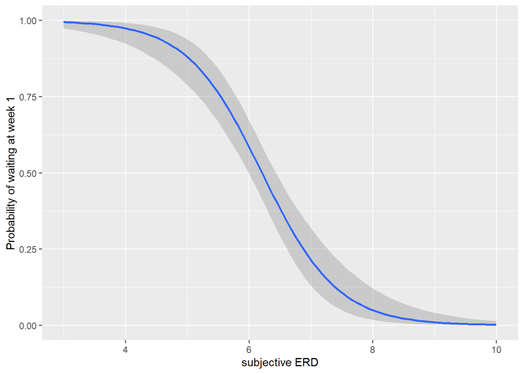

## Perception on MN

### Basic Summary

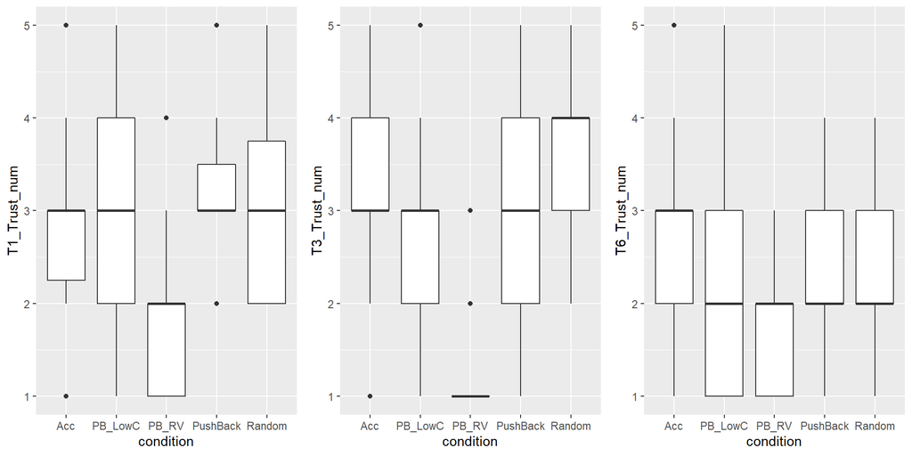

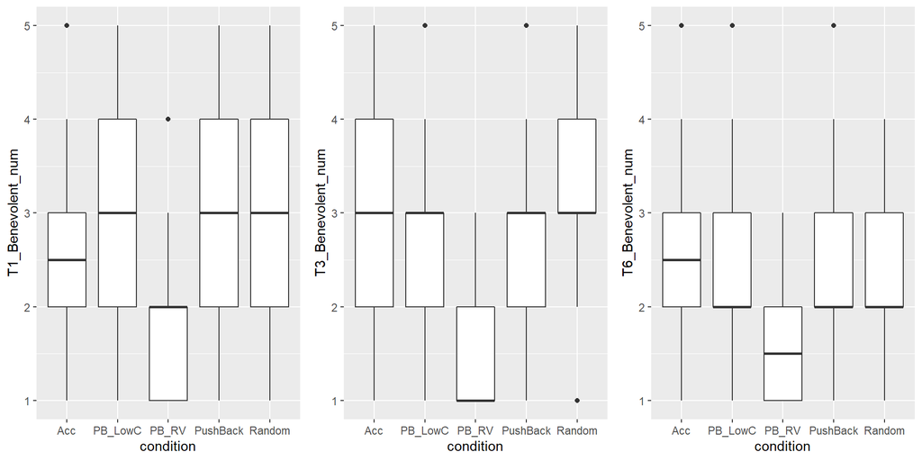

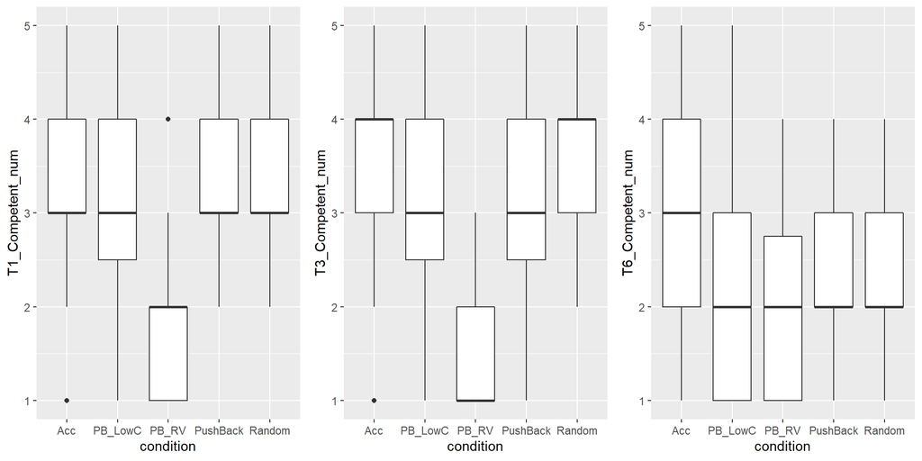

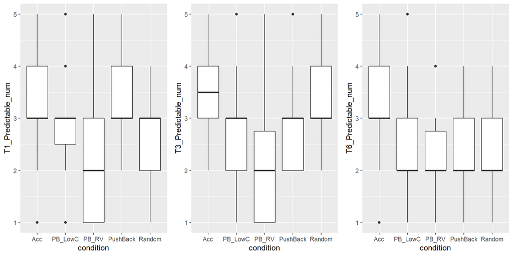

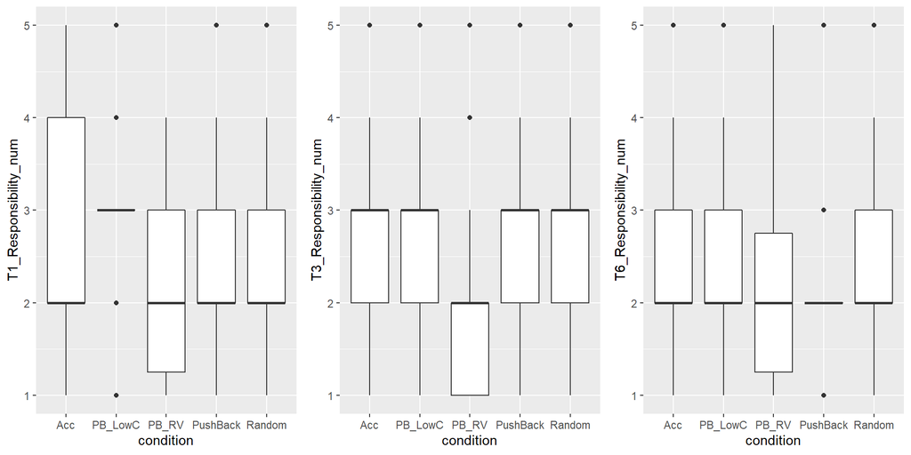

### Correlation

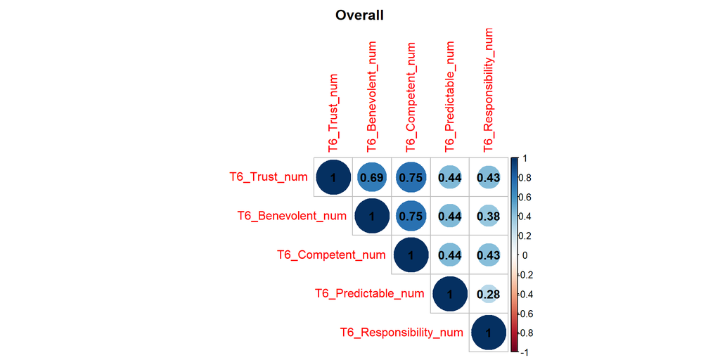

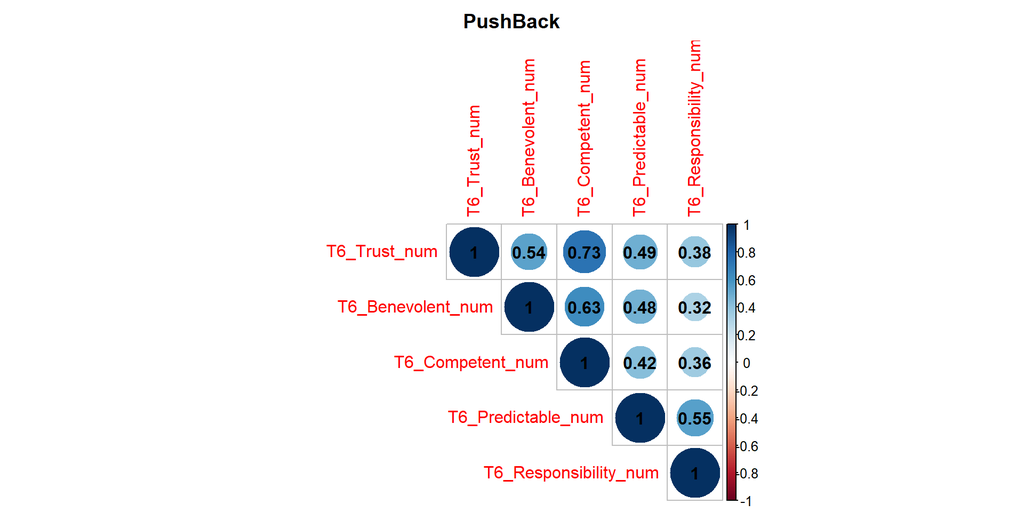

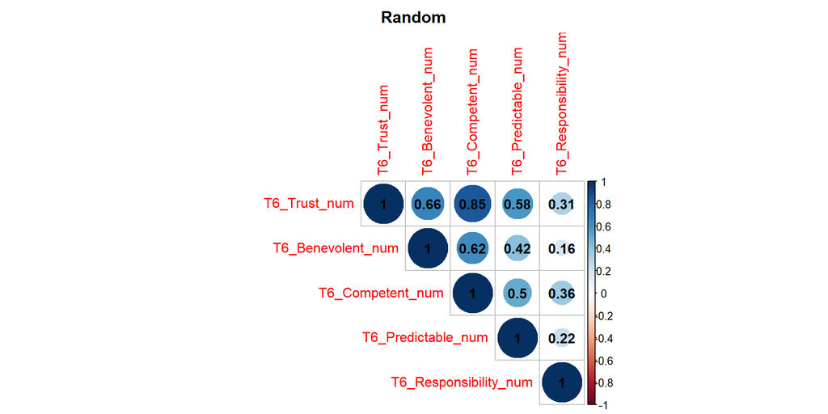

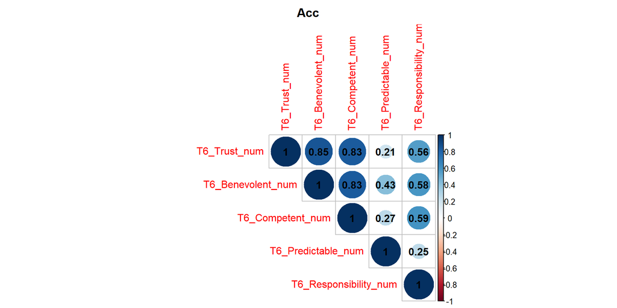

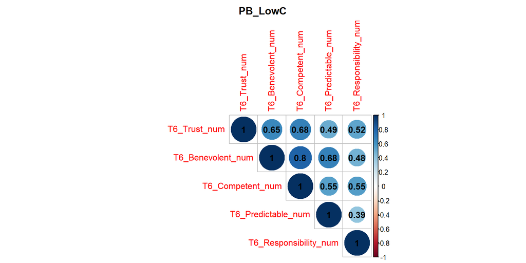

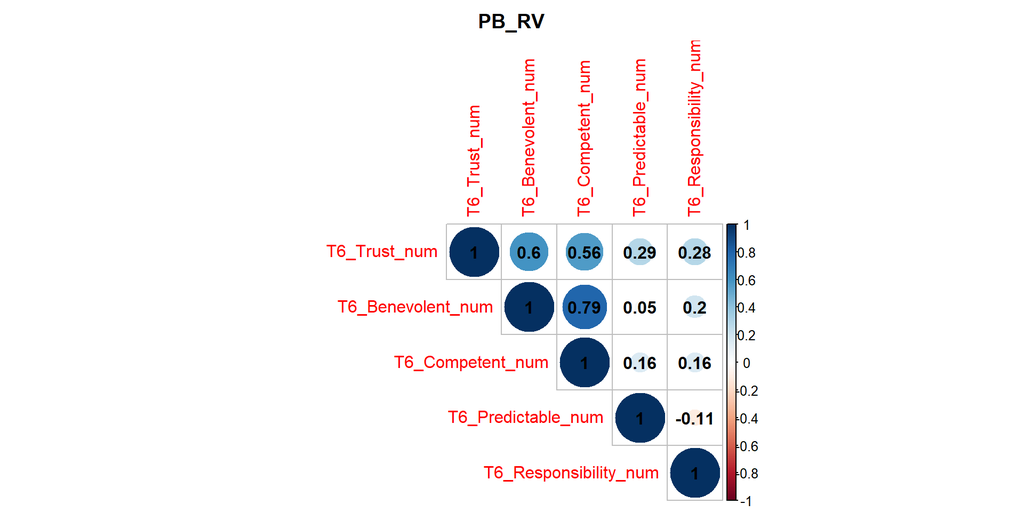

## Fitting results: Predicting T7 W1 Decisions

The following results show the fitting results for predicting decisions on week 1 of Trial 7.

### Using T7 W1 features and T6 Trust features

```
##                          Accuracy TP TN FP FN F1-Score
## Condition                  0.6341 52 52 40 20   0.6341
## T7_W1_Prob                 0.7256 71 48 21 24   0.7594
## T7_W1_Prob + Cond          0.7500 73 50 19 22   0.7807
## T7_W1_ERD                  0.8171 85 49  7 23   0.8500
## T7_W1_ERD + Cond           0.7866 80 49 12 23   0.8205
## T7_W1_ERD + Prob           0.8232 81 54 11 18   0.8482
## T7_W1_ERD + Prob + Cond    0.7988 77 54 15 18   0.8235
## T6_Trust                   0.6159 71 30 21 42   0.6927
## T6_Benevalent              0.6037 73 26 19 46   0.6919
## T6_Competent               0.6341 78 26 14 46   0.7222
## T7_W1_ERD + T6_Competent   0.7805 79 49 13 23   0.8144
```

### Predicting T7 using T1 to T6

```
##                             Accuracy TP TN FP FN F1-Score
## T6_W1_ERD                     0.6402 76 29 16 43   0.7204
## T6_W1_Dec                     0.5976 53 45 39 27   0.6163
## T6_When_Switch                0.4756 77  1 15 71   0.6417
## T6_W1_ERD + cond              0.6890 63 50 29 22   0.7119
## T6_W1_ERD + Decision          0.5915 59 38 33 34   0.6378
## T6_W1_ERD + Decision + cond   0.7073 64 52 28 20   0.7273
```

### Parameter Estimation

```
##                  Estimate Est.Error   Q2.5  Q97.5
## T7_W1_prob          0.065     0.010  0.045  0.086
## T7_W1_ERD          -1.866     0.306 -2.496 -1.294
## T7_W1_Trust         0.639     0.186  0.288  1.004
## T7_W1_Benevolent    0.572     0.179  0.236  0.927
## T7_W1_Competent     0.569     0.174  0.249  0.923
```

### T7 W3 Decision

- Mainly consist of aleardy switch or wait.
- Map already switch and switch (1) into the same category.
- harder to predict in this case, acheiving lower acc.
- Still similar pattern with ERD is better than Prob, achieving ~79% acc.

```
##
## Already_switch         switch           wait
##             74              1             89
```

```
##                         Accuracy TP TN FP FN F1-Score
## T7_W3_Prob                0.7500 69 54 20 21   0.7709
## T7_W3_Prob + Cond         0.7683 72 54 17 21   0.7912
## T7_W3_ERD                 0.7988 85 46  4 29   0.8374
## T7_W3_ERD + Cond          0.7744 73 54 16 21   0.7978
## T7_W3_ERD + Prob          0.7866 72 57 17 18   0.8045
## T7_W3_ERD + Prob + Cond   0.7988 75 56 14 19   0.8197
```

#### The code for Bonus payment

```r
##   Code Bonus payment (Paid)
###  For each trial
### 5 in 20. each batch is 40 so pick out 10. $5 each.

dat_bad$TotalBonus_num     <- as.numeric(dat_bad$TotalBonus)/10000
dat_rand$TotalBonus_num    <- as.numeric(dat_rand$TotalBonus)/10000
dat_acc$TotalBonus_num     <- as.numeric(dat_acc$TotalBonus)/10000
dat_bad_low$TotalBonus_num <- as.numeric(dat_bad_low$TotalBonus)/10000
dat_bad_rv$TotalBonus_num  <- as.numeric(dat_bad_rv$TotalBonus)/10000

seed(777)
bad_id <- sample(1:dim(dat_bad)[1],10,replace=FALSE, prob=dat_bad$TotalBonus_num)
rand_id <- sample(1:dim(dat_rand)[1],10,replace=FALSE, prob=dat_rand$TotalBonus_num)
acc_id <- sample(1:dim(dat_acc)[1],10,replace=FALSE, prob=dat_acc$TotalBonus_num)
bad_low_id <- sample(1:dim(dat_bad_low)[1],10,replace=FALSE, prob=dat_bad_low$TotalBonus_num)
bad_rv_id <- sample(1:dim(dat_bad_rv)[1],10,replace=FALSE, prob=dat_bad_rv$TotalBonus_num)

dat_bad$Prolific_ID[bad_id]
dat_rand$Prolific_ID[rand_id]
dat_acc$Prolific_ID[acc_id]
dat_bad_low$Prolific_ID[bad_low_id]
dat_bad_rv$Prolific_ID[bad_rv_id]
```